## **Input Genomic Region-Level Summary Data**

Completed on: Thu Apr 06 21:33:24 2023 (Asia/Shanghai), with the runtime of (24 seconds).

> **An interactive table** for user-input genomic regions (n=676, being processed). This table has four columns: with 1st column `Input GR` for input genomic regions in the format of `chr:start-end` (genome build `hg19`), 2nd column `Chromosome` for the chromosome, 3rd column `Length` for the region length (bp), 4nd column `Pvalue` for use-input significance information.

| Input GR | Chromosome | Length | Pvalue |
| --- | --- | --- | --- |
| chr20:4090134-4092134 | chr20 | 2001 | 6e-19 |
| chr11:117973237-117975237 | chr11 | 2001 | 3.4e-18 |
| chr1:212634309-212636309 | chr1 | 2001 | 2.2e-17 |
| chr1:212635821-212637821 | chr1 | 2001 | 5.2e-17 |
| chr20:4081996-4083996 | chr20 | 2001 | 1.6e-15 |
| chr17:36127082-36129082 | chr17 | 2001 | 1.6e-15 |
| chr17:36143118-36145118 | chr17 | 2001 | 1.6e-15 |
| chr17:36132988-36134988 | chr17 | 2001 | 5.2e-15 |
| chr1:212637708-212639708 | chr1 | 2001 | 1.7e-14 |
| chr2:113097209-113099209 | chr2 | 2001 | 2.3e-14 |

[output cut: 666 more lines]

## **Output: Linked Genes**

> **Linked Gene table** contains information on genes (n=701, linked from the input genomic regions), including the column `GScores` (ranged from 1 to 10) that quantifies the degree to which genes are likely modulated by input genomic regions. `Linked genes` are sorted by their linked gene scores and are hyperlinked to [GeneCards](https://www.genecards.org) for further information. Please refer to **`Evidence table`** for details on the linking evidence.

| Linked genes | GScores | Description |
| --- | --- | --- |
| NENF | 10 | neudesin neurotrophic factor |
| ATF3 | 9.48 | activating transcription factor 3 |
| NSL1 | 9.369 | NSL1 component of MIS12 kinetochore complex |
| TATDN3 | 9.369 | TatD DNase domain containing 3 |
| HNF1B | 9.233 | HNF1 homeobox B |
| VASH2 | 9.225 | vasohibin 2 |
| ANGEL2 | 9.18 | angel homolog 2 |
| FLVCR1 | 9.125 | FLVCR heme transporter 1 |
| DTL | 9.006 | denticleless E3 ubiquitin protein ligase homolog |
| INTS7 | 9.006 | integrator complex subunit 7 |

[output cut: 691 more lines]

> **Evidence table** displays information about the genomic regions (listed under the column `GR`) that overlap the input genomic regions (listed under the column `Input GR`). The overlapped regions are used to define linked genes (listed under the column `Linked genes`) based on the evidence provided (see the column `Evidence`). The column `Evidence` indicates the datasets used, such as `Proximity` for genomic regions in proximity, the prefix `PCHiC_` for promoter capture Hi-C datasets, and the prefix `ABC_` for enhancer-gene map (ABC) datasets.

| Input GR | GR | Linked genes | Evidence |
| --- | --- | --- | --- |
| chr1:212635821-212637821 | chr1:212637664-212638563 | NENF | ABC_Encode_Combined |
| chr1:212637708-212639708 | chr1:212639646-212641797 | NENF | ABC_Encode_Combined |
| chr1:212637708-212639708 | chr1:212639646-212641797 | ATF3 | ABC_Encode_Combined |
| chr1:212637708-212639708 | chr1:212639646-212641797 | NSL1 | ABC_Encode_Combined |
| chr1:212637708-212639708 | chr1:212639646-212641797 | TATDN3 | ABC_Encode_Combined |
| chr17:36132988-36134988 | chr17:36134323-36134884 | HNF1B | ABC_Encode_Combined |
| chr1:212637708-212639708 | chr1:212639646-212641797 | VASH2 | ABC_Encode_Combined |
| chr1:212637708-212639708 | chr1:212639646-212641797 | ANGEL2 | ABC_Encode_Combined |
| chr1:212637708-212639708 | chr1:212639646-212641797 | FLVCR1 | ABC_Encode_Combined |
| chr1:212637708-212639708 | chr1:212639646-212641797 | DTL | ABC_Encode_Combined |

[output cut: 2937 more lines]

## **Output: Gene Subnetwork**

> **A network visualisation** of the subnetwork, with 33 genes/nodes color-coded by linked gene scores (ranged from 1 to 10). An editable pdf file is also available for download.

DOWNLOAD .pdf

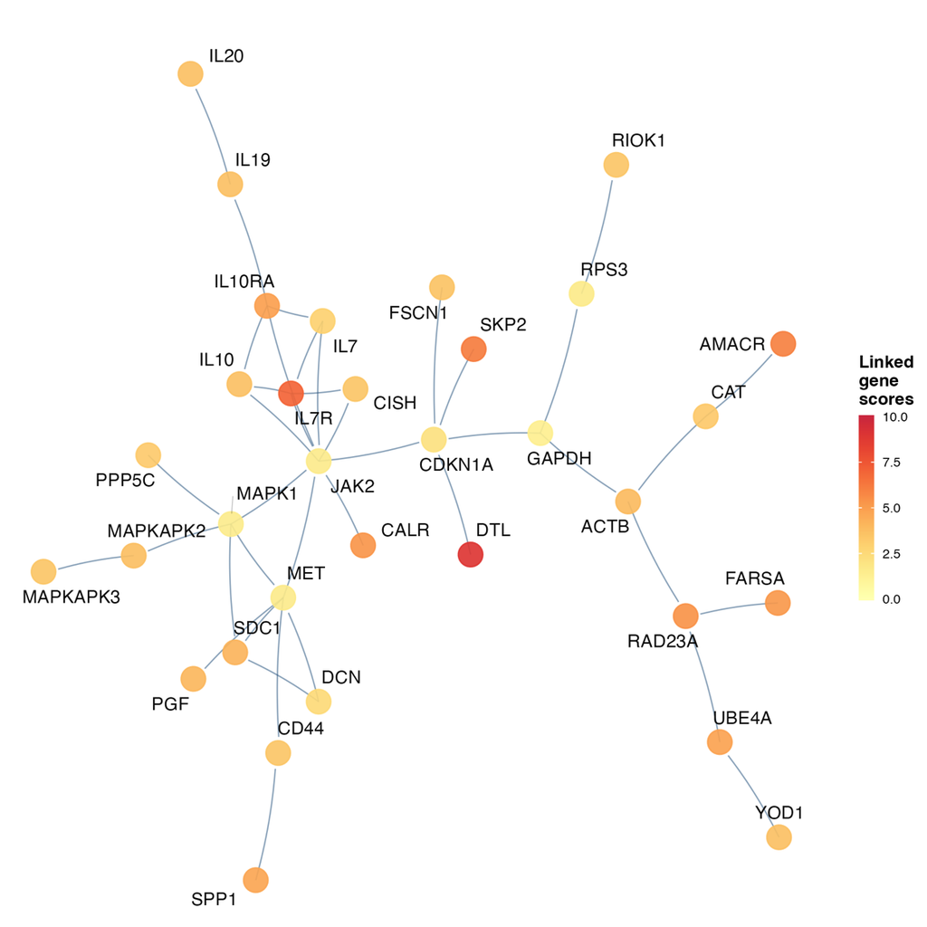

Figure 1: Visualisation of the subnetwork, with genes/nodes color-coded by linked gene scores (ranged from 1 to 10).

> **An interactive table** for the subnetwork genes (n=33), with the column `GScores` for linked gene scores (ranged from 1 to 10). `Linked genes` are hyperlinked to [GeneCards](https://www.genecards.org).

| Linked genes | GScores | Description |
| --- | --- | --- |
| DTL | 9.006 | denticleless E3 ubiquitin protein ligase homolog |
| IL7R | 7.035 | interleukin 7 receptor |
| SKP2 | 6.194 | S-phase kinase associated protein 2 |
| AMACR | 6.048 | alpha-methylacyl-CoA racemase |
| RAD23A | 5.43 | RAD23 homolog A, nucleotide excision repair protein |
| CALR | 5.345 | calreticulin |
| FARSA | 5.243 | phenylalanyl-tRNA synthetase subunit alpha |
| IL10RA | 4.974 | interleukin 10 receptor subunit alpha |
| UBE4A | 4.865 | ubiquitination factor E4A |
| SPP1 | 4.731 | secreted phosphoprotein 1 |

[output cut: 23 more lines]